# Proyecto Final

#### Aprendizaje Máquina

> - Salvador Garcilita
> - José Andrés Villanueva
> - Vianey Galindo Añel

## Patrones espaciales en la distribución del halcón murcielaguero en México

El halcón murcielaguero (Falco rufigularis) es una especie de ave rapaz perteneciente a la familia Falconidae (orden: Falconiformes) ampliamente distribuida en América; históricamente, se encuentra desde el sur de Sonora y Tamaulipas (siendo México el extremo norte de su distribución), distribuyendose a lo largo del país en tierras bajas tropicales y subtropicales de hasta 1500 msnm; el resto de su distribución abarca centroamérica casi en su totalidad y se extiende hasta Ecuador, Perú, Bolivia, Paraguay, Argentina y Brasil; no obstante, es probable que su distribución y abundancia actual hayan cambiado considerablemente, contemplando el intenso cambio de uso de suelo y destrucción de hábitat al que se ha visto sometido el neotrópico, además del uso indiscriminado de pesticidas como el Dicloro Difenil Tricloroetano (DDT). Se ha propuesto la existencia de tres subespecies en F. rufigularis; F. r. petoensis, F. r. rufigularis y F. r. ophryophanes; la subespecie perteneciente a México y centroamérica es petoensis y, al igual que las demás, no se considera migratoria, con individuos establecidos a menudo en parejas en el mismo sitio durante todo el año, y en el caso de los juveniles, dispersandose de las áreas de cría y realizando si acaso migraciones locales. No obstante, la población de México aún perteneciendo a la misma subespecie, dada la heterogeneidad del medio respecto a biomas y ejes montañosos, es probable que pueda ser dividida en distintas subpoblaciones si se usan las herramientas adecuadas y se cuenta con los suficientes datos. F. rufigularis, dada su amplia distribución y abundancia en hábitats propicios, se encuentra listado en la categoría de menor preocupación (Least Concern) de la lista roja de la Unión Internacional para la Conservación de la Naturaleza (IUCN, por sus siglas en inglés), no obstante, se estima que su tendencia poblacional es decreciente.

Una de las particularidades más notorias de las aves como grupo de estudio, es el importante aporte que realizan miembros de la sociedad que no están especializados en la toma de datos debido al interés que despiertan en la gente; estos datos registrados por aficionados poseen gran valor ecológico y deben contemplarse para actualizar y mejorar el estado de conocimiento de las especies, así como fortalecer los lazos entre el sector académico y la sociedad. En particular, eBird es una iniciativa de ciencia ciudadana del Laboratorio de Ornitología de Cornell y la Sociedad Nacional Audubon creada en 2002, que permite recopilar de forma masiva datos colectados por observadores de aves (científicos ciudadanos) usando protocolos estandarizados. Esta fuente de datos puede ser y ha sido aprovechada para evaluar y adaptar las estrategias de conservación de aves en distintas partes del mundo, puesto que ofrece la posibilidad de mejorar nuestro entendimiento de las aves, los hábitats que requieren y cómo protegerlas.

El nicho ecológico es un concepto que ayuda a explicar la distribución geográfica de una especie dentro de un ecosistema, contemplando factores bióticos y abióticos, así como el papel de los individuos dentro de éste. El modelado de nicho ecológico es útil para diversas áreas de estudio, donde se toman decisiones contemplando información biológica y estadística procesada con ayuda de Sistemas de Información Geográfica (SIG) y otras herramientas digitales como lenguajes de programación, que permiten analizar grandes cantidades de datos. Su objetivo es modelar los requisitos ambientales de la especie y así poder identificar las áreas adecuadas para ella, además es usada para la predicción de distribuciones, proponer áreas de conservación e incluso mapeo de información de importancia médica como aumento en la distribución de especies que son vectores de enfermedades; Existen tres principios que deben ser contemplados al escoger las variables predictivas: variables cuyos valores no son afectados por la especie, evitar el uso de variables puramente espaciales, y usar variables causales. La construcción de estos modelos es un proceso de clasificación que debe generar un valor numérico y reciben diferentes denominaciones según su interpretación; en los registros de la especie el investigador debe prestar especial atención al margen de error y sesgo que puedan existir en la dispersión, las interacciones biológicas y cambios ambientales.

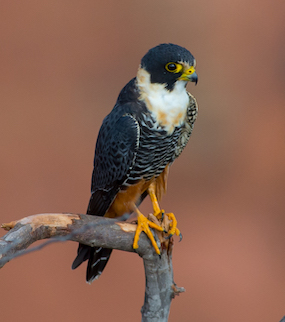

## Metodología

### Obtención y pre-procesamiento de datos

Los datos empleados para el análisis se obtuvieron de la base de datos de eBird (eBird Basic Dataset, 2021), obteniendo los registros de F. rufigularis para los años 2010-2020 a lo largo de todo el país. El procesamiento de datos en éste trabajo se realizó empleando los lenguajes de programación R y Python. Una vez obtenida la base, se empleó el paquete de R AUK para procesar los datos, eliminando registros duplicados debido a las listas compartidas por observadores y manteniendo únicamente registros correspondientes al periodo de años 2010-2020.

#### Visualización de los registros

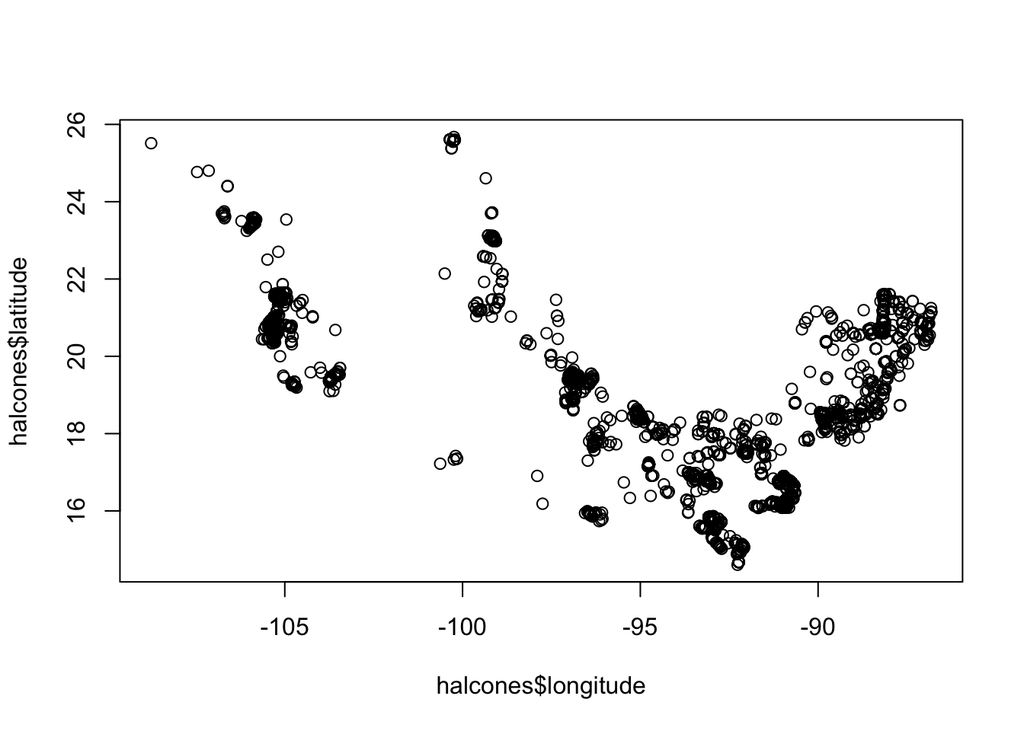

```r
thinned_dataset_full <- thin( loc.data = halcones,
        lat.col = "latitude", long.col = "longitude",
        spec.col = "common_name", #campo con la especie
        thin.par = 5, reps = 10, #thin par es la distancia en km para separar los puntos
        locs.thinned.list.return = TRUE,
        write.files = F,
        max.files = 5, #Numero de posibles soluciones de seleccion
        out.dir = "XXX",
        out.base = "bat_thinned",
        write.log.file = TRUE,
        log.file = "bat_thinned_file.txt" ) #un resumen del proceso y sus resultados


 bat <- thinned_dataset_full[1] %>%
        as.data.frame()
```

### Modelo de distribucion espacial

Se realizó un modelo de nicho ecológico para la especie, considerando las 19 variables ambientales de WorldClim, las cuales fueron: (BIO1) temperatura media anual, (BIO2) rango diurno medio, (BIO3) isotermalidad, (BIO4) estacionalidad de la temperatura, (BIO5) temperatura máxima del mes más cálido, (BIO6) temperatura mínima del mes más frío, (BIO7) rango anual de temperatura, (BIO8) temperatura media del trimestre más húmedo, (BIO9) temperatura media del cuarto más seco, (BIO10) temperatura media del trimestre más cálido, (BIO11) temperatura media del cuarto más frío, (BIO12) precipitación anual, (BIO13) precipitación del mes más húmedo, (BIO14) precipitación del mes más seco, (BIO15) estacionalidad de la precipitación, (BIO16) precipitación del cuarto más húmedo, (BIO17) precipitación del cuarto más seco, (BIO18) precipitación del trimestre más cálido, (BIO19) precipitación del cuarto más frío. Para implementar esto fue necesario el uso de las librerias especializdas maptools, raster y dismo.

```r
library(rsample)
library (maptools)
library(raster)
library(dismo)
library(randomForest)
library(rpart)
library(ggplot2)

set.seed(0)
bat <- read.csv("./bat_thinned_file.csv", header = TRUE)

data("wrld_simpl")

# variables  bioclimaticas predictoras
wc <- raster::getData("worldclim", var = "bio", res = 10)

# extraer datos climáticos de las ubicaciones de nuestras observaciones.
clima_bat <- raster::extract(wc, bat[,1:2])
head(clima_bat)
```

```
##      bio1 bio2 bio3 bio4 bio5 bio6 bio7 bio8 bio9 bio10 bio11 bio12 bio13 bio14
## [1,]  253  118   62 2194  344  155  189  263  251   276   221  1174   227    26
## [2,]  248  118   62 2248  339  149  190  259  245   271   215  1118   199    24
## [3,]  250  107   60 2091  334  158  176  260  247   271   219  1226   215    30
## [4,]  246  110   61 2163  333  153  180  257  243   268   215  1202   206    30
## [5,]  252  109   61 2086  338  160  178  262  250   275   222  1244   233    30
## [6,]  248  118   62 2248  339  149  190  259  245   271   215  1118   199    24
##      bio15 bio16 bio17 bio18 bio19
## [1,]    63   535    88   294   126
## [2,]    59   468    93   308   129
## [3,]    57   516   100   323   147
## [4,]    56   493   101   325   146
## [5,]    60   554    98   315   143
## [6,]    59   468    93   308   129
```

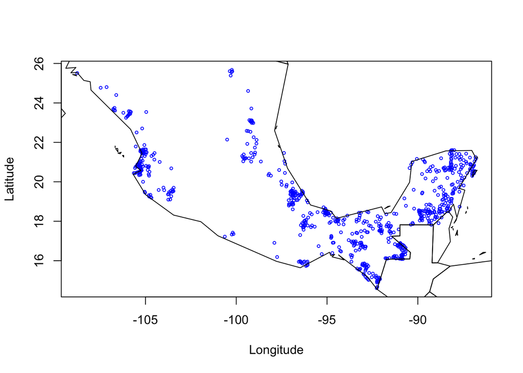

```r
# añado columna de presencia 1 / ausencia 0
pa <- c(rep(1, 668))
clima_bat <- cbind(clima_bat, pa)

#### análisis exploratorio
plot(bat[,1:2], cex = 0.5, col = "blue")
plot(wrld_simpl, add = T)
```

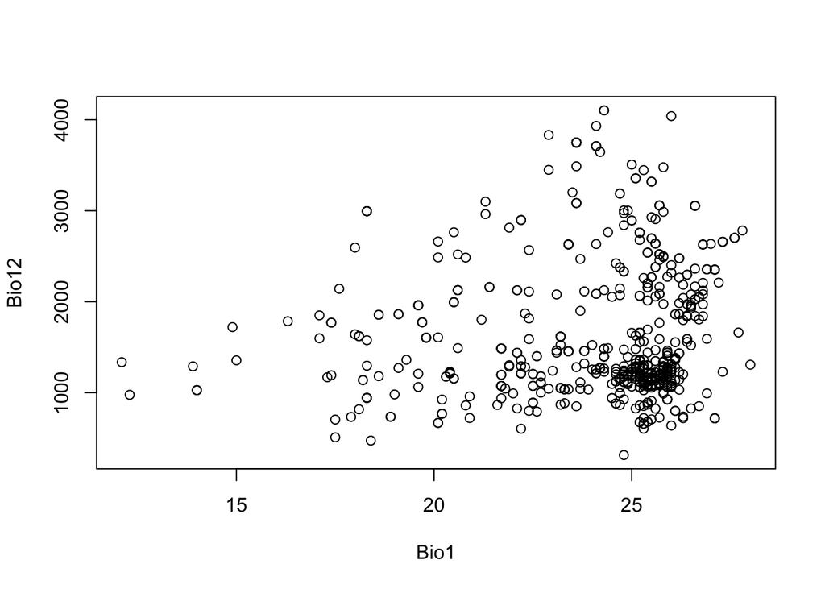

```r
# BIo 1: Annual Mean Temperature
# Bio 12: Annual precipitation
plot(clima_bat[,1]/10, clima_bat[,12], xlab = "Bio1", ylab = "Bio12")
```

```r
### modelamiento de presencia vs random expectation.
# definicion random expectation: también llamada background, o random absence data,
# es lo que obtendrías si la especie no tuviera ninguna preferencia por ninguna de
# las variables predictora (u otras variables que no estén correlacionadas con las
# variables predictoras).

# la extensión de la distribución de la especie
ext <- raster::extent(SpatialPoints(bat[,1:2]))

mex <- getData("GADM", country = "MEX", level = 1)

# generamos 3000 muestras aleatorias de extent
random_ar <- sampleRandom(wc, 3000, ext = ext) # ext = para limitar el muestreo al
# área dentro de la extensión.

# generamos columna de presencia 1 ausencia 0
par <- c(rep(0, 3000))
random_ar <- cbind(random_ar, par)

bat_completor <- rbind(clima_bat, random_ar) %>%
  as.data.frame()

bat_split <- initial_split(bat_completor, strata = pa)
train_data <- training(bat_split)
test_data <- testing(bat_split)

cart <- rpart(pa~., data=train_data)

#para encontrar el hiperparametro mtry
trf <- tuneRF(train_data[, 1:19], train_data[, 'pa'])
```

```
## mtry = 6  OOB error = 0.1237212
## Searching left ...
## mtry = 3     OOB error = 0.1209218
## 0.02262607 0.05
## Searching right ...
## mtry = 12    OOB error = 0.1221528
## 0.01267647 0.05
```

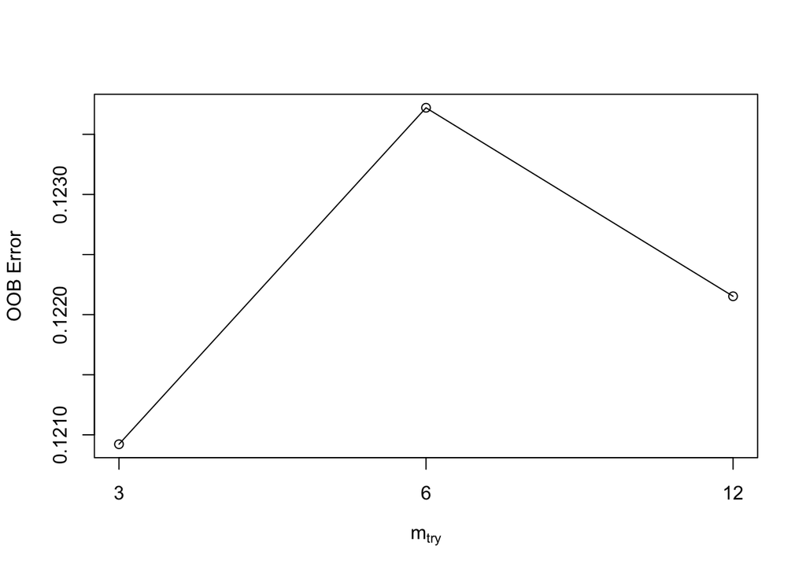

```r
mt <- trf[which.min(trf[,2]), 1]
mt
```

```
## [1] 3
```

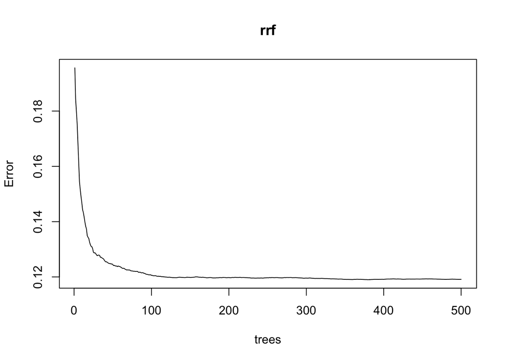

```r
rrf <- randomForest(train_data[, 1:19], train_data[, 'pa'], mtry=mt)
plot(rrf)
```

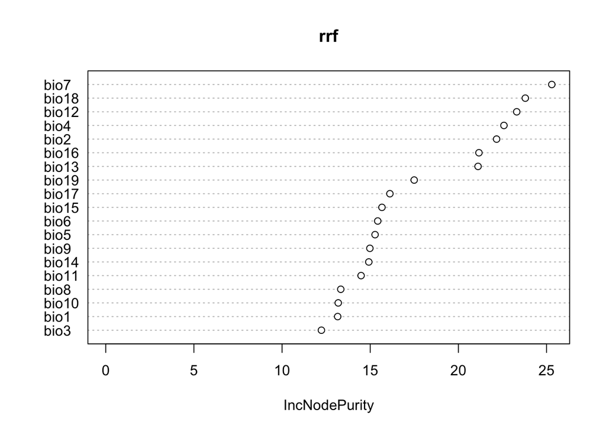

```r
varImpPlot(rrf)
```

```r
eva <- evaluate(test_data[test_data$pa==1, ], test_data[test_data$pa==0, ], rrf)
eva
```

```
## class          : ModelEvaluation
## n presences    : 167
## n absences     : 750
## AUC            : 0.8258802
## cor            : 0.4434351
## max TPR+TNR at : 0.1391333
```

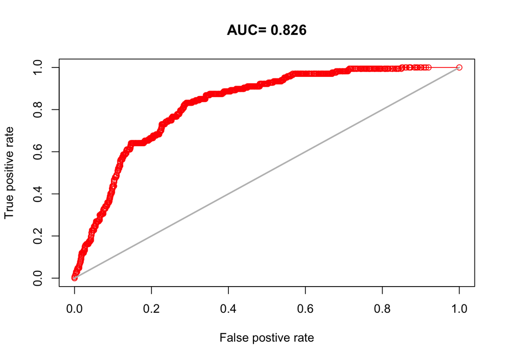

```r
plot(eva, 'ROC')
```

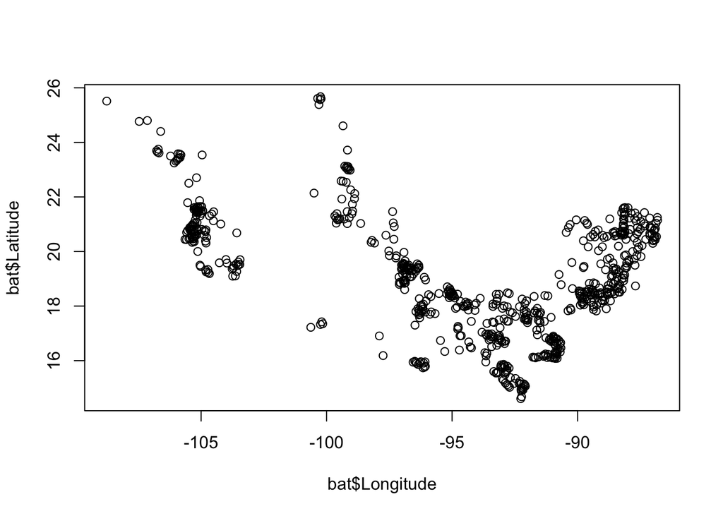

```r
#predictions
rp <- predict(wc, rrf, ext=mex)
plot(bat$Longitude, bat$Latitude)
```

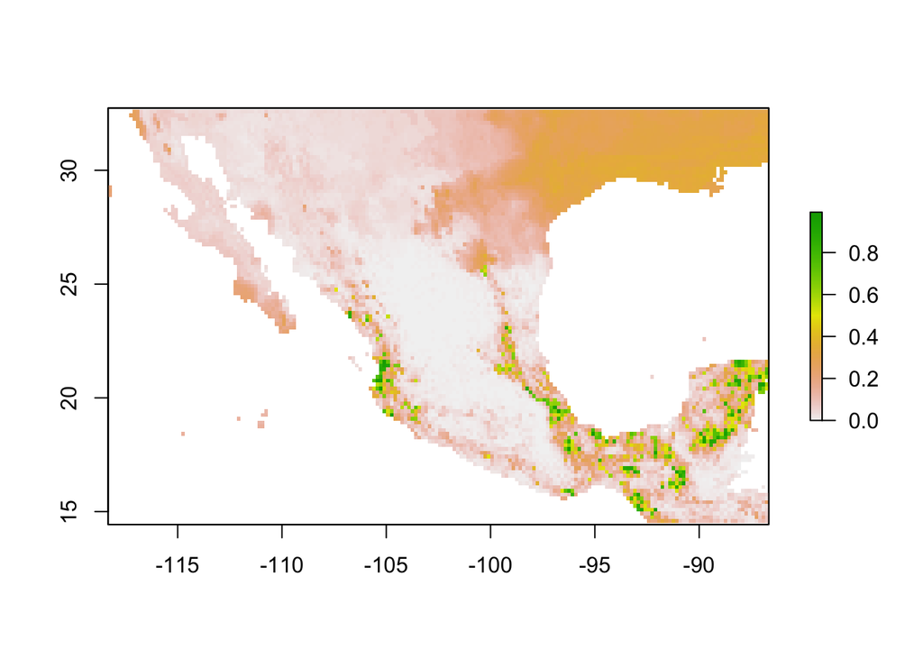

```r
plot(rp)
```

### Regionalización de poblaciones

Para entender la distribución de la especie en el país y su potencial agrupamiento en subpoblaciones, se aplicó un algoritmo DBSCAN (Density-Based Spatial Clustering of Applications with Noise, por sus siglas en inglés), una técnica de agrupamiento de aprendizaje de máquina basado en densidad de puntos que permite clasificar en grupos datos no etiquetados de forma no supervisada y que tiene un desempeño apropiado con datos espaciales . DBSCAN requiere de tres parámetros (en el contexto del Machine Learning, hiper parámetros) que fueron definidos por nosotros; 1) un valor epsilon, que es el criterio de distancia mínima entre dos puntos para ser considerados vecinos y formar un grupo (subpoblación en el contexto del presente trabajo), 2) mínimo de muestras, que es la cantidad mínima de registros agrupados para ser considerados un grupo y no valores atípicos (registros aislados) y 3) una métrica para calcular la distancia entre puntos.

Para elegir el valor más apropiado para epsilon, se realizó primero un modelo de vecinos más cercanos (Nearest Neighbours), otro algoritmo de aprendizaje de máquina que agrupa los datos en función de un número de clusters determinado por el investigador, permitiendo calcular la distancia a los n puntos más cercanos de cada registro, ordenarlos y posteriormente graficarlos para observar el valor óptimo de epsilon, el cual se ve reflejado como el punto de máxima curvatura.

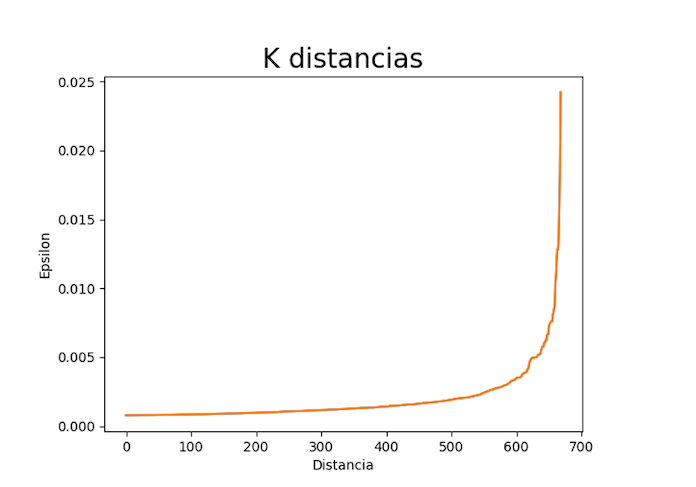

Curva de puntos ordenados por distancia para determinación del parámetro épsilon.

```python
import pandas as pd
import numpy as np
import matplotlib.pyplot as plt
import seaborn as sns
from sklearn.neighbors import NearestNeighbors
from sklearn.cluster import DBSCAN
import geopandas as gpd

# aquí hay que conectar la tubería, en el chunk anterior se crea el objeto bat como data frame en R. Aquí hay que conectar ese data frame con un pandas data frame.

bat = pd.read_csv("./Bat_thinned_file.csv")

# la primera columna del arreglo debe ser latitud
latitud = bat["latitude"]

# la segunda columna del arreglo debe ser longitud
longitud = bat["longitude"]

# creo un data frame con el orden necesario:
bat = pd.DataFrame([latitud, longitud]).transpose()

# Ajustamos el modelo de Nearest Neighbours transformando los valores en radianes
neigh = NearestNeighbors(metric = 'haversine', n_neighbors=5)
nbrs = neigh.fit(np.radians(bat))
distances, _ = nbrs.kneighbors(np.radians(bat))

# Ordenamos las distancias de menor a mayor y observamos el punto (distancia) donde se presenta la mayor curvatura (punto de inflexión en las distancias)
distances = np.sort(distances, axis=0)
distances = distances[:,1]
plt.plot(distances)
plt.xlabel("Distancia")
plt.ylabel("Epsilon")
plt.title("K distancias", fontsize=20)
plt.show()
```

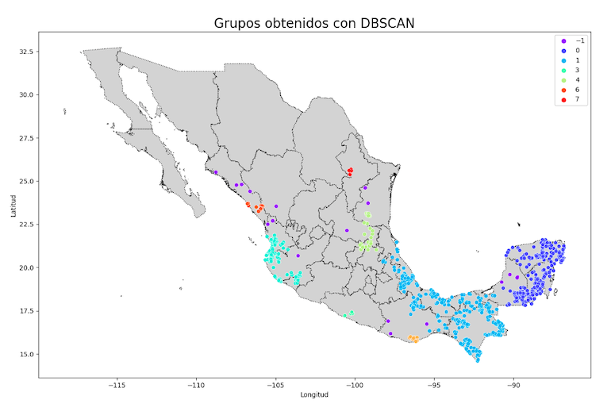

Agrupamiento de registros de F. rufigularis con el algoritmo DBSCAN.

```python
# Ajustamos el modelo transformando los valores en radianes
dbscan = DBSCAN(eps=0.010, min_samples=4, metric='haversine') # mejores parámetros so far: eps=0.010, min=4

# vale la pena explorar más combinaciones...
dbscan.fit(np.radians(bat))

# Obtenemos la etiqueta del clúster para cada observación
clusters = dbscan.labels_

## parte espacial: mapa de mexico (CARGAR .SHAPE DE MÉXICO).
mexico = gpd.read_file(".shp")

## grafica sobre mapa
ax = mexico.plot(color = "lightgrey", linestyle = ":", edgecolor = "black")
sns.scatterplot(data = bat, x ="longitude", y = "latitude", hue = clusters,  palette="rainbow", ax=ax)
plt.xlabel("Longitud")
plt.ylabel("Latitud")
plt.title("Grupos obtenidos con DBSCAN", fontsize=20)
plt.show()
```

## Resultados

Respecto al agrupamiento de los registros, el algoritmo DBSCAN arrojó ocho grupos, con lo cual podríamos entender que la población total de F. rufigularis en México se divide en 8 subpoblaciones (etiquetadas de cero a siete). En color morado y con etiqueta -1, se representan los datos atípicos (o ruido, en el contexto de éste algoritmo), los cuales son registros que no cumplieron con el criterio de permanencia a ningún grupo por la proximidad.